**Momentum and Impulse**

By Prof. Seungchul Lee  
http://iai.postech.ac.kr/  
Industrial AI Lab at POSTECH

Table of Contents

# 1. Concept of Momentum

- an alternate variable (to velocity) to describe translational motion that is particularly powerful when describing the motion of a multi-body system.
- The momentum of a system is unaffected by internal forces - forces between two objects that are both inside the system.
- Momentum is changed only by external forces - forces on any part of the system that arise from interactions with objects outside of the system.
- For systems that experience no external forces, momentum is constant (or conserved).

**Momentum**

$$\vec{p}^{system} = \sum_i m_i\vec{\upsilon}_i$$

**Impulse**

Impulse (which is given the symbol $J$) is defined by:

$$\vec{J} = \int_{t_i}^{t_f} \sum_i \vec{F}^{ext}\;dt$$

for the net force acting over a time interval $t_i$ to $t_f$.

# 2. Collision (Linear Motions)

- Forces
  - Internal forces act between the objects in the system
  - External forces act between objects in the system and the environment
- Conservation of momentum in isolated systems
  - An isolated system is a collection of objects that may interact interanlly, but where the net external force on all the objects is zero. For an isolated system, the total momentume is conserved.

**2.1. Complete Elastic Collision**

$$\text{before}$$

$$\text{after}$$

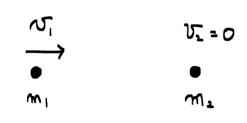

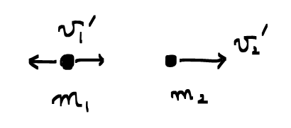

- needs two equations

  1) momentum conservation (system: $m_1 + m_2$)
  $$m_1 \upsilon_1 = m_1 \upsilon_1 ' + m_2 \upsilon_2'$$
  2) if complete elastic (*i.e.*, kinetic energy conserved)
  $$ \frac{1}{2}m_1 \upsilon_1^2 = \frac{1}{2}m_1 \upsilon_1'^2 + \frac{1}{2}m_2 \upsilon_2'^2$$
- general solution $$ \begin{align*} \upsilon_1'^2 & = \left( \frac{m_1 - m_2}{m_1 + m_2} \right)\upsilon_1 \\ \upsilon_2'^2 & = \left( \frac{2 m_1}{m_1 + m_2}\right)\upsilon_1 \qquad \text{positive direction} \end{align*} $$
  1) $m_1 \gg m_2 \;(m_2 \Rightarrow 0)$ $$ \begin{align*} \upsilon_1' & = \upsilon_1\\ \upsilon_2' & = 2 \upsilon_1 \qquad \text{not intuitive} \end{align*} $$
  2) $m_1 \ll m_2 \;(m_1 \Rightarrow 0)$ $$ \begin{align*} \upsilon_1' & = -\upsilon_1\\ \upsilon_2' & = 0 \end{align*} $$
  3) $m_1 = m_2$ $$ \begin{align*} \upsilon_1' & = 0 \\ \upsilon_2' & = \upsilon_1 \end{align*} $$
  4) $2 m_1 = m_2$ $$ \begin{align*} \upsilon_1' & = -\frac{1}{3}\upsilon_1 \\ \upsilon_2' & = \frac{2}{3}\upsilon_1 \end{align*} $$

```matlab
%%html
<iframe
width="420" height="315" src="https://www.youtube.com/embed/ZY8VnjKlAJM" frameborder="0" allowfullscreen>
</iframe>
```

[video not shown]

```matlab
%%html
<iframe
width="420" height="315" src="https://www.youtube.com/embed/5VRx6dD7es8" frameborder="0" allowfullscreen>
</iframe>
```

[video not shown]

```matlab
%%html
<iframe
width="420" height="315" src="https://www.youtube.com/embed/vbxgAmgtaq4" frameborder="0" allowfullscreen>
</iframe>
```

[video not shown]

Collision simulator (optional)

- `processing`

```matlab
%%processing
int m1 = 20;
int m2 = 10;
float v1 = 3;
float v2 = -3;

PVector x1;
PVector x2;

void setup() {
  size(700, 300);
  background(255);

  x1 = new PVector(200, height/2);
  x2 = new PVector(width-200, height/2);

  fill(100);
  ellipse(x1.x, x1.y, 2*m1, 2*m1);
  ellipse(x2.x, x2.y, 2*m2, 2*m2);
}

void draw() {
  background(255);

  x1.x += v1;
  x2.x += v2;

  fill(100);
  ellipse(x1.x, x1.y, 2*m1, 2*m1);
  ellipse(x2.x, x2.y, 2*m2, 2*m2);

  if  ((abs(x1.x-x2.x) <= m1+m2)) {

    float temp1 = ((m1-m2)*v1+2*m2*v2)/(m1 + m2);
    float temp2 = ((m2-m1)*v2+2*m1*v1)/(m2 + m1);
    v1 = temp1;
    v2 = temp2;
  }
}
```

[interactive chart not shown]

**2.2. Question**

```matlab
%%html
<iframe
width="420" height="315" src="https://www.youtube.com/embed/YLTu9pGz_7U" frameborder="0" allowfullscreen>
</iframe>
```

[video not shown]

**2.3. Complete Inelastic Collision**

$$\text{before}$$

$$\text{after}$$

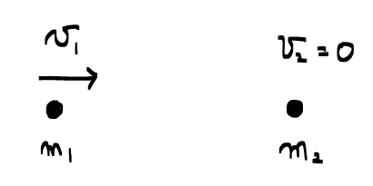

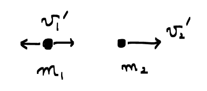

1) momentum conservation

$$m_1 \upsilon_1 = m_1 \upsilon_1 ' + m_2 \upsilon_2'$$

2) if complete inelastic

$$ \upsilon_1' = \upsilon_2' $$

- general solution

$$ \begin{align*} \upsilon_1'^2 & = \left( \frac{m_1}{m_1 + m_2} \right)\upsilon_1 \\ \upsilon_2'^2 & = \left( \frac{m_1}{m_1 + m_2}\right)\upsilon_1 \end{align*} $$

```matlab
%%html
<iframe
width="420" height="315" src="https://www.youtube.com/embed/0u10y7FPlRE" frameborder="0" allowfullscreen>
</iframe>
```

[video not shown]

**2.3. Explosion**

- initially a spring is compressed, then it is cut

  $$\text{before}$$

  $$\text{after}$$

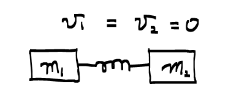

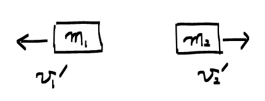

1) momentum conservation

2) if mechanical energy conserved

$$\frac{1}{2}kx^2 = \frac{1}{2}m_1 \upsilon_1'^2 + \frac{1}{2}m_2 \upsilon_2'^2 $$

```matlab
%%html
<iframe
width="560" height="315" src="https://www.youtube.com/embed/1e2s1uRCQFc?list=PLBD_gON7g_m0tzxOabPd4afo28xBK0cCX"
frameborder="0" allowfullscreen>
</iframe>
```

[video not shown]

**Example 1: Momentum + Kinetic Energy**

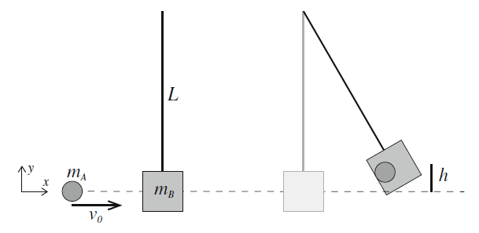

**Example 2: Momentum + Kinetic Energy**

(b) How high does the pendulum swing after the collision?

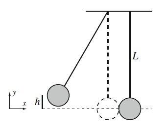

**Example 3: Super-ball**

```matlab
%%html
<iframe
width="560" height="315" src="https://www.youtube.com/embed/7poxIuT8TSg" frameborder="0" allowfullscreen>
</iframe>
```

[video not shown]

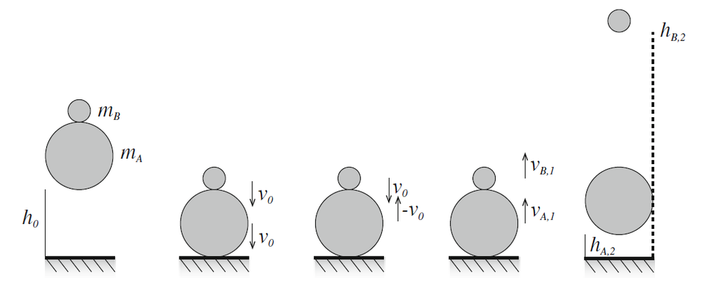

**Example 4: Rocket**

```matlab
%%html
<iframe
width="560" height="315" src="https://www.youtube.com/embed/ccUNtsu8hLI" frameborder="0" allowfullscreen>
</iframe>
```

[video not shown]

$$\text{before}$$

$$\text{after}$$

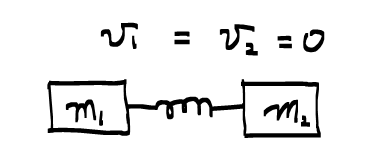

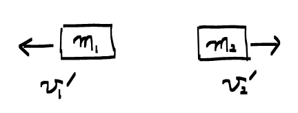

**Question**

- Think about how to escape from a frozen lake (no friction ice)

# 3. Impulse

Impulse (which is given the symbol $J$) is defined by:

$$\vec{J} = \int_{t_i}^{t_f} \sum_i \vec{F}^{ext}\;dt$$

for the net force acting over a time interval $t_i$ to $t_f$.

- Impulse Causes Change in Momentum

$$\vec J = \Delta \vec p = \vec{m}_{t_f} - \vec{m}_{t_i} = \vec{F}_{\text{avg}} \,\delta t$$

```matlab
%%html
<iframe
width="420" height="315" src="https://www.youtube.com/embed/fdeH6Ksedwk"
frameborder="0" allowfullscreen></iframe>
```

[video not shown]

```matlab
%%html
<iframe width="420" height="315" src="https://www.youtube.com/embed/MGO6BxQ-MJk"
frameborder="0" allowfullscreen></iframe>
```

[video not shown]

```matlab
%%html
<iframe width="420" height="315" src="https://www.youtube.com/embed/5xHDCFevMQk"
frameborder="0" allowfullscreen></iframe>
```

[video not shown]

# 4. Angular Momentum

$$ \vec L = \vec r \times \vec p = I \vec{\omega}$$

- Direction of angular momentum
- It is also conserved when no external torque
- Riding a bicycle

```matlab
%%html
<iframe
width="560" height="315" src="https://www.youtube.com/embed/sy5NY-Dqdys"
frameborder="0" allowfullscreen></iframe>
```

[video not shown]

```matlab
%%javascript
$.getScript('https://kmahelona.github.io/ipython_notebook_goodies/ipython_notebook_toc.js')
```